# Key Drivers of Transmission Type in Vehicles

Sean Schilk

10/5/2025

The key behind simple logistic regression is that we are working with a binary response variable, meaning only 2 outcomes, success or failure, for example. Let’s practice SLR with a provided dataset by R

```r
# ?mtcars # look for binary variable, we will use am here for our response
data(mtcars)
mtcars.0 <- mtcars # copy for cleansing
Transmission <- na.omit(mtcars.0)

#0 = automatic, 1 = manual
head(Transmission)
```

```
                   mpg cyl disp  hp drat    wt  qsec vs am gear carb
Mazda RX4         21.0   6  160 110 3.90 2.620 16.46  0  1    4    4
Mazda RX4 Wag     21.0   6  160 110 3.90 2.875 17.02  0  1    4    4
Datsun 710        22.8   4  108  93 3.85 2.320 18.61  1  1    4    1
Hornet 4 Drive    21.4   6  258 110 3.08 3.215 19.44  1  0    3    1
Hornet Sportabout 18.7   8  360 175 3.15 3.440 17.02  0  0    3    2
Valiant           18.1   6  225 105 2.76 3.460 20.22  1  0    3    1
```

```r
# weight is our predictor
```

There were no missing values.

# 1 Exploratory Data Analysis

Since we only study the simple logistic regression model, only one predictor variable is included in the model. We first perform exploratory data analysis on the predictor variable to make sure the variable is not extremely skewed

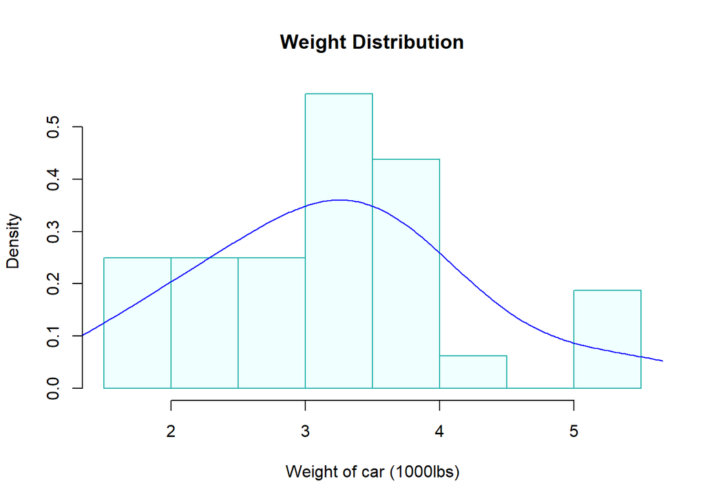

```r
ylimit = max(density(Transmission$wt)$y)   # find the highest point on the density curve.
hist(Transmission$wt, probability = TRUE,
     main = "Weight Distribution",
     xlab="Weight of car (1000lbs)",
     col = "azure1",
     border="lightseagreen")
  lines(density(Transmission$wt, adjust=2), col="blue")
```

Slightly right skewed, but no transformation is necessary for this predictor at this stage.

Let’s check to see if our response, am, has a class imbalance. This will be the case if there’s a 90/10 split for the binary response variable

```r
table(Transmission$am)
```

```
 0  1
19 13
```

```r
# 19 / 32 total = 59/41 split, pretty good
```

From a modeling perspective, this distribution does not indicate a class imbalance that would bias the results

# 2 Building Logistic Regression Model

```r
s.logit = glm(am ~ wt,
              family = binomial(link = "logit"),
              data = Transmission)

result = summary(s.logit)
result
```

```
Call:
glm(formula = am ~ wt, family = binomial(link = "logit"), data = Transmission)

Coefficients:
            Estimate Std. Error z value Pr(>|z|)
(Intercept)   12.040      4.510   2.670  0.00759 **
wt            -4.024      1.436  -2.801  0.00509 **
---
Signif. codes:  0 '***' 0.001 '**' 0.01 '*' 0.05 '.' 0.1 ' ' 1

(Dispersion parameter for binomial family taken to be 1)

    Null deviance: 43.230  on 31  degrees of freedom
Residual deviance: 19.176  on 30  degrees of freedom
AIC: 23.176

Number of Fisher Scoring iterations: 6
```

The response variable am is a binary factor. the reference level is 0, which would be a car being automatic.

The summary of major statistics is given below:

```r
library(pander)
model.coef.stats = summary(s.logit)$coef       # output stats of coefficients
conf.ci = confint(s.logit)                     # confidence intervals of betas
sum.stats = cbind(model.coef.stats, conf.ci.95=conf.ci)   # rounding off decimals
pander(sum.stats,caption = "The summary stats of regression coefficients")
```

The summary stats of regression coefficients

|  | Estimate | Std. Error | z value | Pr(>\|z\|) | 2.5 % | 97.5 % |
| --- | --- | --- | --- | --- | --- | --- |
| **(Intercept)** | 12.04 | 4.51 | 2.67 | 0.007588 | 5.214 | 23.63 |
| **wt** | -4.024 | 1.436 | -2.801 | 0.005088 | -7.699 | -1.833 |

As shown in the table, weight demonstrates a negative association with transmission type, with a coefficient of -4.024 and a pvalue close to zero. This finding is supported by the 95% confidence interval of [-7.699, -1.833], which excludes the null value of zero, and is consistent with existing literature.

From a practical perspective, it is more common to interpret the results using the odds ratio. Therefore, we now convert the estimated regression coefficients into odds ratios.

```r
# Odds ratio
model.coef.stats = summary(s.logit)$coef
odds.ratio = exp(coef(s.logit))
out.stats = cbind(model.coef.stats, odds.ratio = odds.ratio)
pander(out.stats,caption = "Summary Stats with Odds Ratios")
```

Summary Stats with Odds Ratios

|  | Estimate | Std. Error | z value | Pr(>\|z\|) | odds.ratio |
| --- | --- | --- | --- | --- | --- |
| **(Intercept)** | 12.04 | 4.51 | 2.67 | 0.007588 | 169460 |
| **wt** | -4.024 | 1.436 | -2.801 | 0.005088 | 0.01788 |

The odds ratio for weight is .02, indicating for that each one-unit (1000lb) increase in weight, the odds of a car having a manual transmission decreases by about 98%. This makese sense as heavier cars are usually built for comfort, like luxury sedans, large cruisers, SUVs / heavy vehicles which are more likely to be automatic as they focus on a smoother experience.

Several global goodness-of-fit measures for the model are summarized in the following table.

```r
## Other global goodness-of-fit
dev.resid = s.logit$deviance
dev.0.resid = s.logit$null.deviance
aic = s.logit$aic
goodness = cbind(Deviance.residual =dev.resid, Null.Deviance.Residual = dev.0.resid,
      AIC = aic)
pander(goodness)
```

| Deviance.residual | Null.Deviance.Residual | AIC |
| --- | --- | --- |
| 19.18 | 43.23 | 23.18 |

Since the above global goodness-of-fit is based on the log-likelihood (LL) function, we don’t have other candidate models with corresponding likelihood at the same scale to compare in this simple logistic regression model, we will not interpret these goodness-of-fit measures.

The success probability curve (so-called S curve) is given below.

[figure not shown]

```r
wt.range = range(Transmission$wt)
x = seq(wt.range[1], wt.range[2], length = 200)
beta.x = coef(s.logit)[1] + coef(s.logit)[2]*x
success.prob = exp(beta.x)/(1+exp(beta.x))
failure.prob = 1/(1+exp(beta.x))
ylimit = max(success.prob, failure.prob)
##
beta1 = coef(s.logit)[2]
success.prob.rate = beta1*exp(beta.x)/(1+exp(beta.x))^2
##
##
par(mfrow = c(1,2))
plot(x, success.prob, type = "l", lwd = 2, col = "navy",
     main = "The probability of being \n  a manual transmission",
     ylim=c(0, 1.1*ylimit),
     xlab = "wt",
     ylab = "probability",
     axes = FALSE,
     col.main = "navy",
     cex.main = 0.8)
# lines(x, failure.prob,lwd = 2, col = "darkred")
axis(1, pos = 0)
axis(2)
# legend(30, 1, c("Success Probability", "Failure Probability"), lwd = rep(2,2),
#       col = c("navy", "darkred"), cex = 0.7, bty = "n")
##
y.rate = max(success.prob.rate)
plot(x, success.prob.rate, type = "l", lwd = 2, col = "navy",
     main = "The rate of change in the probability \n  of being a manual transmission",
     xlab = "wt",
     ylab = "Rate of Change",
     ylim=c(0,1.1*y.rate),
     axes = FALSE,
     col.main = "navy",
     cex.main = 0.8
     )
axis(1, pos = 0)
axis(2)
```

This analysis could be improved by incorporating additional variables. We also used a small sample size here.